# **[Universidade Federal Rural de Pernambuco](http://ufrpe.br/)** **[Departamento de Matemática](http://www.dm.ufrpe.br/)** **[Disciplina: Análise Combinatória](https://sites.google.com/site/ricardonunesmachadojr/disciplinas/analise-combinatoria)** **[Prof. Ricardo Machado](https://sites.google.com/site/ricardonunesmachadojr/)**

## [Índice de Aulas](https://sagectu.com.br/calculo1.github.io/index.html) Aula 3

## 1 - Permutação Circular 2 - Permutação com Repetição

# Referências:

### Observação: Nota de aula produzida usando o software [SageMath](http://www.sagemath.org/), usando o notbook [Jupyter](https://jupyter.org/). Use o SageMathCell com vários exemplos em: sagectu.com.br/sagecell.html Referência bibliográfica sobre o SageMath: [1] Silva, L., Santos M., Machado, R., [*Elementos de Computação Matemática com SageMath*](https://sagectu.com.br/), SBM, 2019.

[figure not shown]

```python
P(n)=factorial(n)
C(n, p) = binomial(n,p)
```

## 1 - Permutação Circular

## O número de permutações circulares de $n$ elementos, é o número de maneiras de organizar $n$ objetos distintos ao longo de um círculo fixo (isto é, não pode ser retirado do plano e virado). Notação: $$ PC(n) $$

## Exemplo O três circulos seguintes são equivalentes na permutação circular.

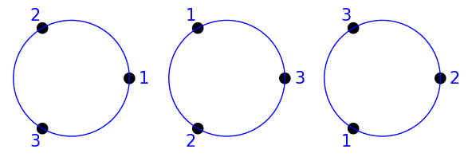

```python
p1 = permuta_circular_x([1, 2, 3])
p2 = permuta_circular_x([3, 1, 2])
p3 = permuta_circular_x([2, 3, 1])
G = graphics_array([[p1, p2, p3]])
G.show()
```

## Exemplo O número total de permutações circulares com 3 elementos $\{1, 2, 3\}$ é 2.

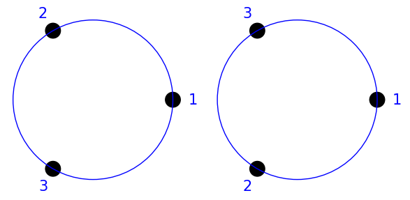

```python
p1 = permuta_circular_x([1, 2, 3])
p2 = permuta_circular_x([1, 3, 2])
G = graphics_array([[p1, p2]])
G.show()
```

## Teorema $$ PC(n) = (n-1)! $$

## Demonstração. Se não considerássemos equivalentes disposições que possam coincidir por rotação, teríamos $n!$ disposições. Como para cada disposição, temos $n$ disposições equivalentes, temos $$ PC(n) = \frac{n!}{n} = (n-1)! $$ $\blacksquare$

```python
PC(n) = P(n)/n
```

## Exemplo. Quantas rodas de ciranda podem ser formadas com 8 pessoas? $\blacksquare$

## Solução. Basta calcular o número de permutações circulares de 8 elementos. $ $ $$ PC(8) $$ $\blacksquare$

```python
PC(8)
```

```
5040
```

## Exemplo. Quantas rodas de ciranda podem ser formadas com 8 pessoas, se duas determinadas pessoas não podem ficar juntas?

## Solução. Podemos calcular o número de permutações circulares de 8 elementos e subtrair o número de permutações de 8 elementos, na qual, dois deles estão juntos.

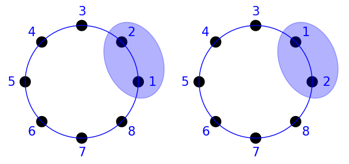

```python
p1 = permuta_circular_x([1, 2, 3, 4, 5, 6, 7, 8]) + ellipse((cos(pi/8), sin(pi/8)), 0.5, 0.7, pi/8, fill='true', alpha=0.3)
p2 = permuta_circular_x([2, 1, 3, 4, 5, 6, 7, 8]) + ellipse((cos(pi/8), sin(pi/8)), 0.5, 0.7, pi/8, fill='true', alpha=0.3)

G = graphics_array([[p1, p2]])
G.show()
```

## Neste caso, teremos $PC(7)\times 2$. Portanto a resposta é $ $ $$ PC(8)-PC(7)\times2 $$ $\blacksquare$

```python
PC(8)-PC(7)*2
```

```
3600
```

## 2 - Permutação com Repetição

## Quando temos um conjunto de $n$ objetos, que possua elementos repetidos, o número de permutações desses $n$ objetos, é chamado de permutação com repetição. Notação $ $ $$ PR_n^{r_1, r_2, \ldots, r_m}. $$ Na qual, $r_i$ é o número de repetições do i-ésimo objeto.

## Exemplo. Quantos são os anagramas da palavra SAGEMATH?

## Solução Observe que a palavra SAGEMATH possui 8 letras, mas a letra A aparece duas vezes, o restante aparece apenas uma vez. Podemos imaginar, por enquanto, que a palavra é assim $$SA_1GEMA_2TH$$ Com $A_1\neq A_2$, nesse caso teríamos um total de $$ P(8) = 8! $$ permutações. Agora vamos resolver o problema das repetições. Observe que para cada permutação, trocar os A's de lugar não muda o anagrama, portanto, podemos dividir o total de permutações pela quantidade de rearranjar os A's. Dessa forma a resposta é $$\frac{P(8)}{P(2)}.$$

```python
P(8)/P(2)
```

```
20160
```

```python
def PR(*lista):

    p = P(lista[0])
    for i in lista[1:]:
        p = p/P(i)

    return p
```

## Exemplo. Quantos são os anagramas da palavra MATEMATICA?

## Solução $$ PR_{10}^{3, 2, 2} $$

```python
PR(10, 3, 2, 2)
```

```
151200
```

## Exemplo. Quantos são os anagramas da palavra MATEMATICA que começam por vogal?

## Solução Se o anagrama começa por vogal, temos as possibilidades, A, E ou I. Começando com A, temos um total de $P_9^{2, 2, 2}$ Começando com E, temos um total de $P_9^{3, 2, 2}$ Começando com I, temos um total de $P_9^{3, 2, 2}$ Portanto a resposta é $$ P_9^{2, 2, 2} + 2\times P_9^{3, 2, 2} $$

```python
P(9, 2, 2, 2) + 2*P(9, 3, 2, 2)
```

[output not shown]